# wk3-bayes-hw

kenwan cheung

4/13/2018

Use formulas to calculate parameters of beta distribution from mode and concentration:

α=ω(κ−2)+1,  
β=(1−ω)(κ−2)+1, κ>2.

```r
o = .05
kappa = 100
a = o*(kappa-2)+1
b = (1-o)*(kappa-2)+1

c(a=a,b=b)
```

```
##    a    b
##  5.9 94.1
```

Shapes

```r
x<-seq(from=0,to=1,by=.001)
priorBetaDens<-dbeta(x,shape1=a,shape2=b)

x[which.max(priorBetaDens)]
```

```
## [1] 0.05
```

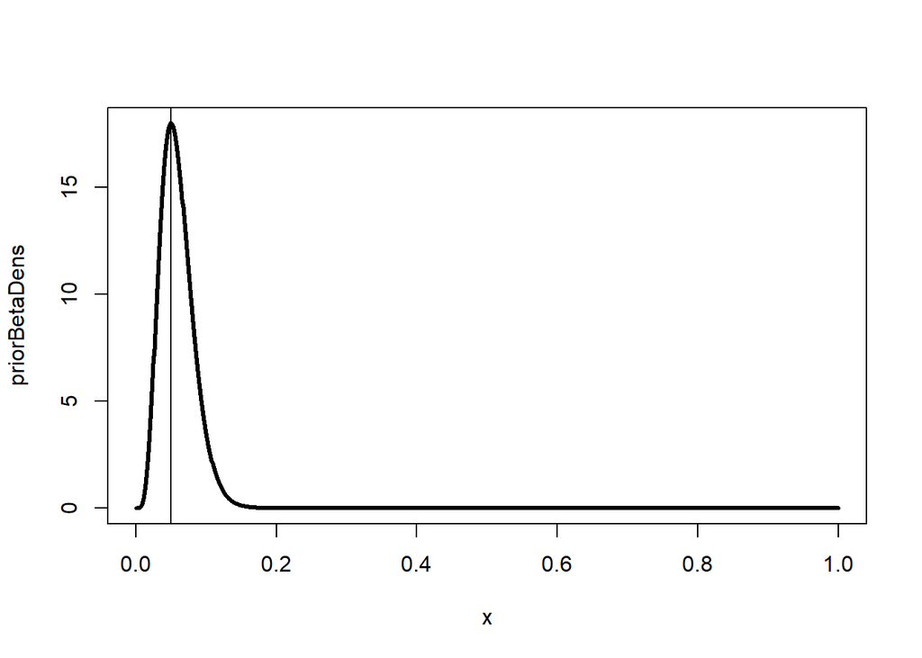

```r
plot(x,priorBetaDens,type="l",lwd=3)
abline(v=.05)
```

Sample - hgher than 5% in sample. but somewhere in between “compromise between”

```r
(smple<-c(rep(0,times=92),rep(1,times=8)))
```

```
##   [1] 0 0 0 0 0 0 0 0 0 0 0 0 0 0 0 0 0 0 0 0 0 0 0 0 0 0 0 0 0 0 0 0 0 0 0
##  [36] 0 0 0 0 0 0 0 0 0 0 0 0 0 0 0 0 0 0 0 0 0 0 0 0 0 0 0 0 0 0 0 0 0 0 0
##  [71] 0 0 0 0 0 0 0 0 0 0 0 0 0 0 0 0 0 0 0 0 0 0 1 1 1 1 1 1 1 1
```

```r
(k<-sum(smple))
```

```
## [1] 8
```

```r
(s<-length(smple))
```

```
## [1] 100
```

Posterior

```r
postA = k + a
postB = s - k + b

c(postA=postA,postB=postB)
```

```
## postA postB
##  13.9 186.1
```

```r
posteriorBetaDens<-dbeta(x,shape1=postA,shape2=postB)

x[which.max(posteriorBetaDens)]
```

```
## [1] 0.065
```

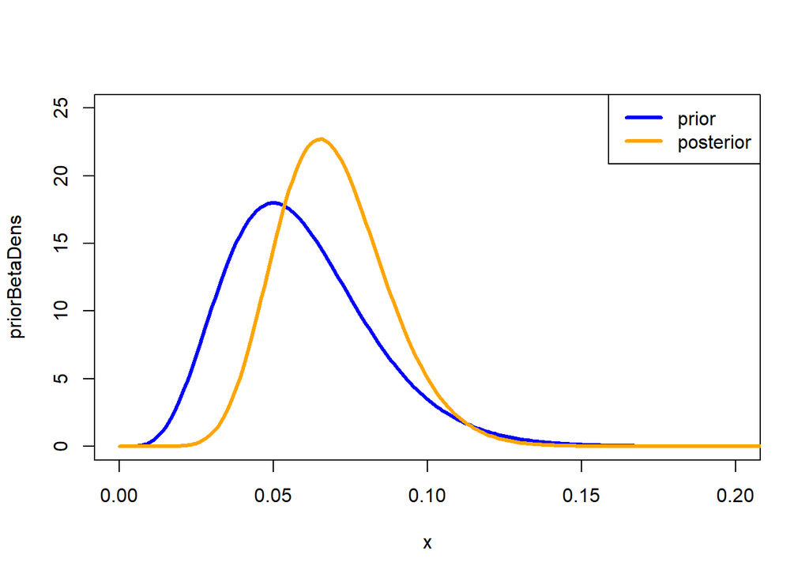

```r
plot(x,priorBetaDens,type='l',lwd=3,col='blue',ylim=c(0,25),xlim=c(0,.2))
lines(x,posteriorBetaDens,lwd=3,col='orange')
legend("topright",legend=c("prior","posterior"),col=c("blue","orange"),lwd=3)
```

moments

```r
(muPosterior=postA/(postA+postB))
```

```
## [1] 0.0695
```

```r
(varPosterior=(postA*postB)/((postA+postB)^2*(postA+postB+1)))
```

```
## [1] 0.00032174
```

```r
(kappaPosterior<-postA+postB)
```

```
## [1] 200
```

part 4

```r
#prior of density beta * conditional prob given.
jointPrior<-function(theta,omega,A_omega,B_omega,K){
  res<-dbeta(omega,A_omega,B_omega)*dbeta(theta,omega*(K-2)+1,(1-omega)*(K-2)+1)
  res
}
```

Step 5

posterior mean

```r
(muPosterior = postA /(postA+postB))
```

```
## [1] 0.0695
```

```r
(varPosterior =postA*postB/((postA+postB)^2*(postA+postB+1)))
```

```
## [1] 0.00032174
```

```r
((kappaPosterior<-postA+postB))
```

```
## [1] 200
```

# sNow we can move onto last part of the workshop.

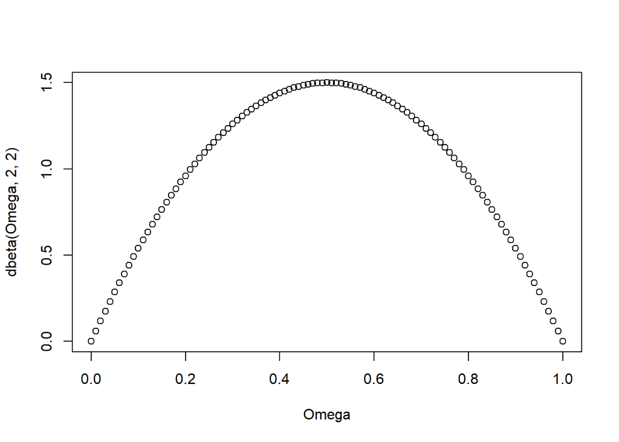

```r
Omega<-Theta<-seq( 0 , 1 , length=101 )
plot(Omega,dbeta(Omega,2,2))
```

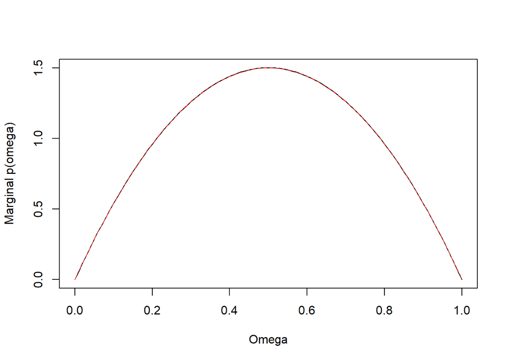

```r
A_omega<-2
B_omega<-2
K<-100

jointPrior<-function(theta,omega,A_omega,B_omega,K){
  res<-dbeta(omega,A_omega,B_omega)*dbeta(theta,omega*(K-2)+1,(1-omega)*(K-2)+1)
  res
}

dens<-expand.grid(Omega,Theta)

colnames(dens)<-c("Omega","Theta")

dens$Prior<-apply(dens,1,function(z) jointPrior(z[1],z[2],A_omega,B_omega,K))

Prior.theta.omega<-matrix(dens$Prior,101,101)
Prior.theta.omega<-Prior.theta.omega/sum(Prior.theta.omega) #Joint prior

Prior.omega.marginal<-apply(Prior.theta.omega,2,sum)
Prior.omega.marginal<-Prior.omega.marginal/sum(Prior.omega.marginal)*100 #Omega marginal prior
matplot(Omega,cbind(Prior.omega.marginal,dbeta(Omega,A_omega,B_omega)),type="l",ylab="Marginal p(omega)")
```

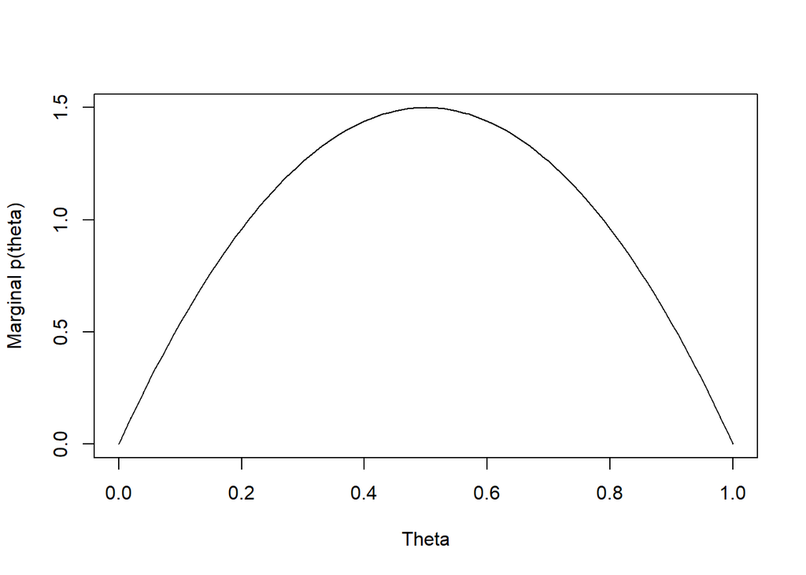

```r
Prior.theta.marginal<-apply(Prior.theta.omega,1,sum)
Prior.theta.marginal<-Prior.theta.marginal/sum(Prior.theta.marginal)*100 #Theta marginal prior
plot(Theta,Prior.theta.marginal,type="l",ylab="Marginal p(theta)")
```

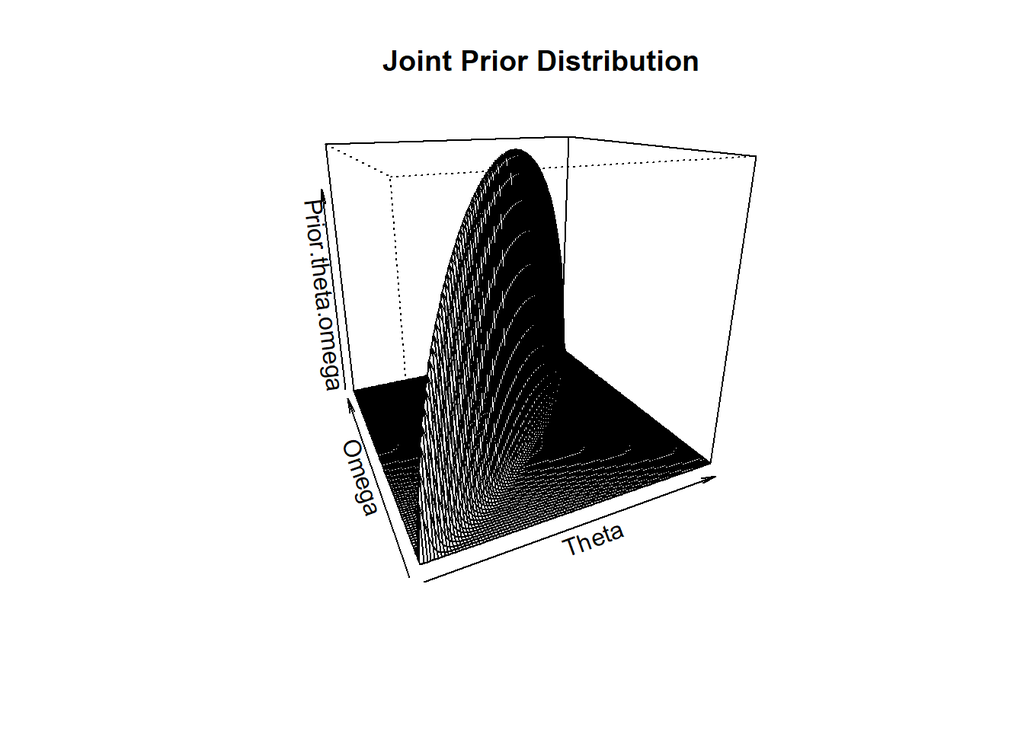

```r
persp(Theta,Omega,Prior.theta.omega,d=1,theta=-25,phi=20,main="Joint Prior Distribution")
```

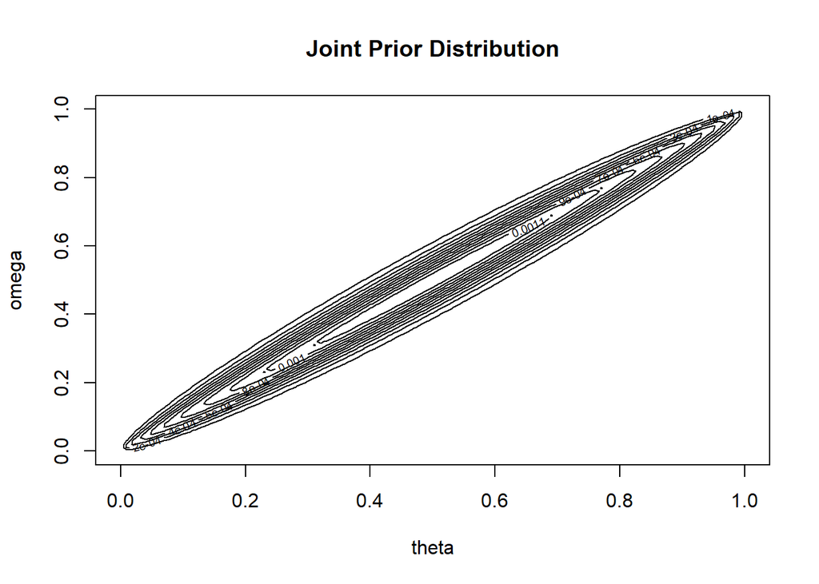

```r
contour(x=Omega,y=Theta,z=Prior.theta.omega,ylab="omega",xlab="theta",main="Joint Prior Distribution")
```

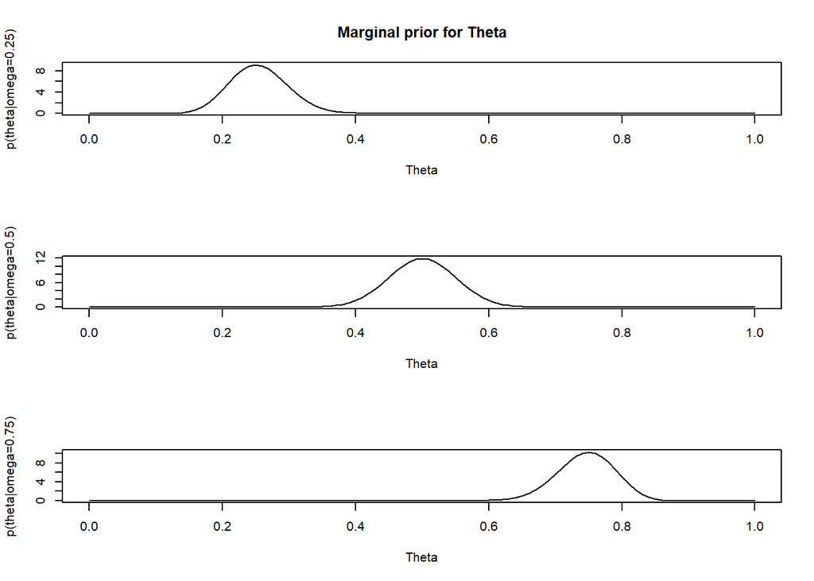

```r
par(mfrow=c(3,1))
Prior.theta.omega.25<-jointPrior(Theta,0.25,A_omega,B_omega,K)
Prior.theta.omega.25<-Prior.theta.omega.25/sum(Prior.theta.omega.25)*100
plot(Theta,Prior.theta.omega.25,type="l",ylab="p(theta|omega=0.25)",main="Marginal prior for Theta")
Prior.theta.omega.5<-jointPrior(Theta,0.5,A_omega,B_omega,K)
Prior.theta.omega.5<-Prior.theta.omega.5/sum(Prior.theta.omega.5)*100
plot(Theta,jointPrior(Theta,0.5,A_omega,B_omega,K),type="l",ylab="p(theta|omega=0.5)")
Prior.theta.omega.75<-jointPrior(Theta,0.75,A_omega,B_omega,K)
Prior.theta.omega.75<-Prior.theta.omega.75/sum(Prior.theta.omega.75)*100
plot(Theta,jointPrior(Theta,0.75,A_omega,B_omega,K),type="l",ylab="p(theta|omega=0.75)")
```

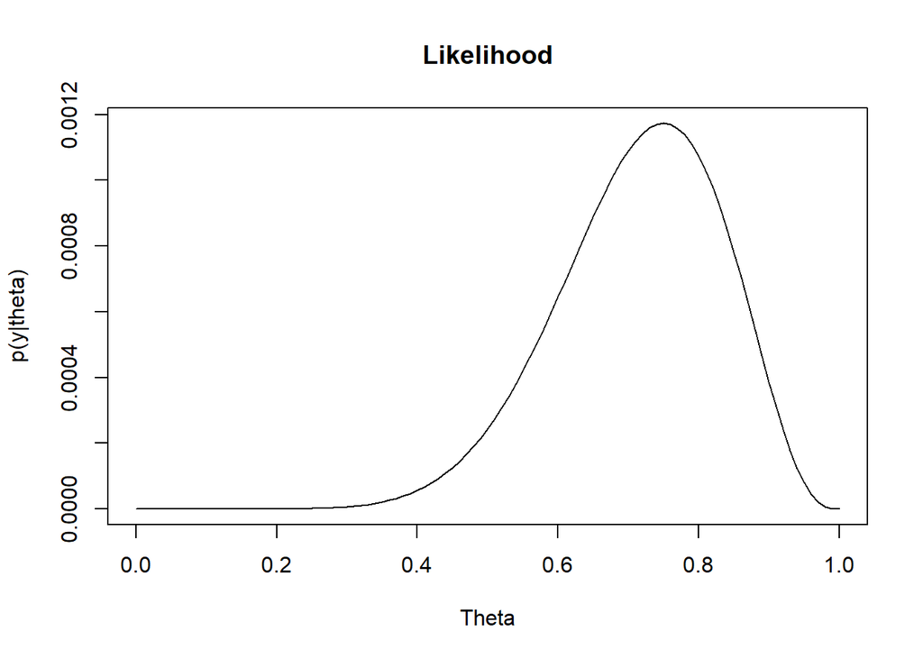

```r
par(mfrow=c(1,1))

likeli<-function(theta,s,k){
  theta^k*(1-theta)^(s-k)
}
likelihood<-likeli(Theta,12,9)
plot(Theta,likelihood,type="l",ylab="p(y|theta)",main="Likelihood")
```

```r
Posterior<-apply(Prior.theta.omega,2,function(z) z*likelihood)
Posterior<-Posterior/sum(Posterior)
```

# Now we can move onto the next section - the rest of the hw!

In example from Section 5.1 of [G] the goal was estimation of the probability of tumor θ in a population of female laboratory rats of type “F344” that receive a zero dose of the drug (control group).

In the experiment 4 out of 14 rats developed a tumor.

```r
Data<-c(s=14,k=4)
```

Select binomial model yi∼Binom(θ) with probability of tumor θ and beta prior distribution for the parameter θ∼Beta(α,β).

Suppose we know from historical observation of population of “F344” the mean and the variance of beta distribution for θ.

Using formulas in the interactive demonstration of beta distribution convert mean value μ=0.136 and standard deviation σ=0.1034 of observed empirical probabilities into shapes of beta distribution α,β.

LLet’s create a function to calculate parameters from a given mean and var

```r
estBetaParams <- function(mu, var) {
  alpha <- ((1 - mu) / var - 1 / mu) * mu ^ 2
  beta <- alpha * (1 / mu - 1)
  return(params = list(alpha = alpha, beta = beta))
}

betaparam = estBetaParams(0.136,(0.1034)^2)
```

Now we can calculate the parameters of the poisterior distribution

```r
k = 4
s = 14

(postA = k + betaparam$alpha)
```

```
## [1] 5.358688
```

```r
(postB = s - k + betaparam$beta)
```

```
## [1] 18.63166
```

Compare prior and posterior distributions and explain the difference.

```r
rbind(cbind(betaparam$alpha,betaparam$beta),cbind(a=postA,b=postB))
```

```
##             a         b
## [1,] 1.358688  8.631663
## [2,] 5.358688 18.631663
```

Discussion: We now have more information with drastically different parameters and the posteriorrepresents the compromise between the weakish prior and posterior.

Assume that probability of tumor θ in control group is concentrated around unknown mode ω of beta distribution with concentration level of 20 (κtheta). In addition ω∼Beta(Aω,Bω).

Belief based on historical observations is that parameter ω has a tendency to be around 0.4 with concentration 12.

Use grid approximation to find posterior distribution

```r
mode = .4
K = 12

(A_omega = mode*(K-2)+1)
```

```
## [1] 5
```

```r
(B_omega = (1-mode)*(K-2)+1)
```

```
## [1] 7
```

Now that we’ve initialized let’s move on.

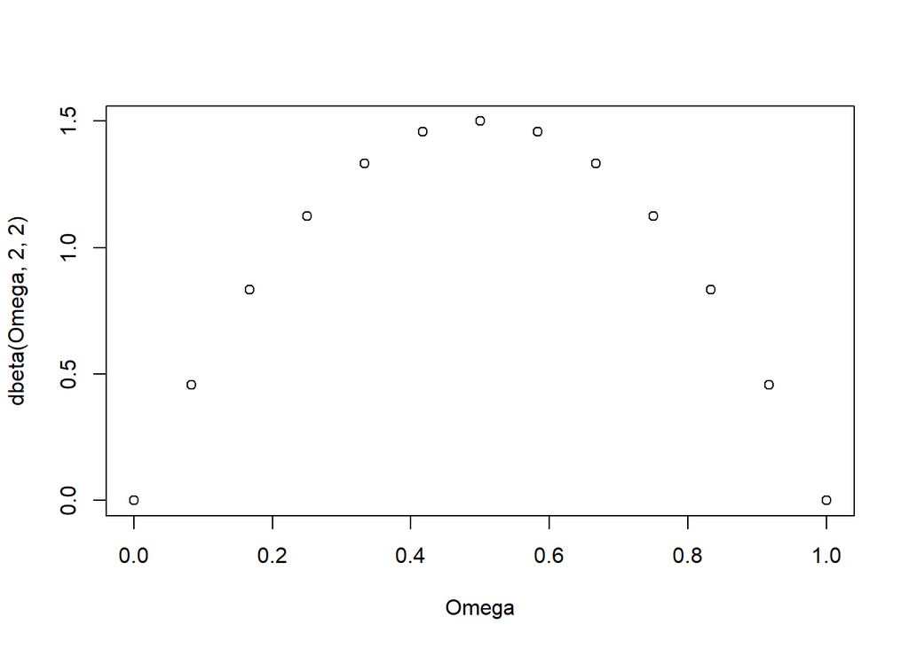

```r
Omega<-Theta<-seq( 0 , 1 , length=13 )
plot(Omega,dbeta(Omega,2,2))
```

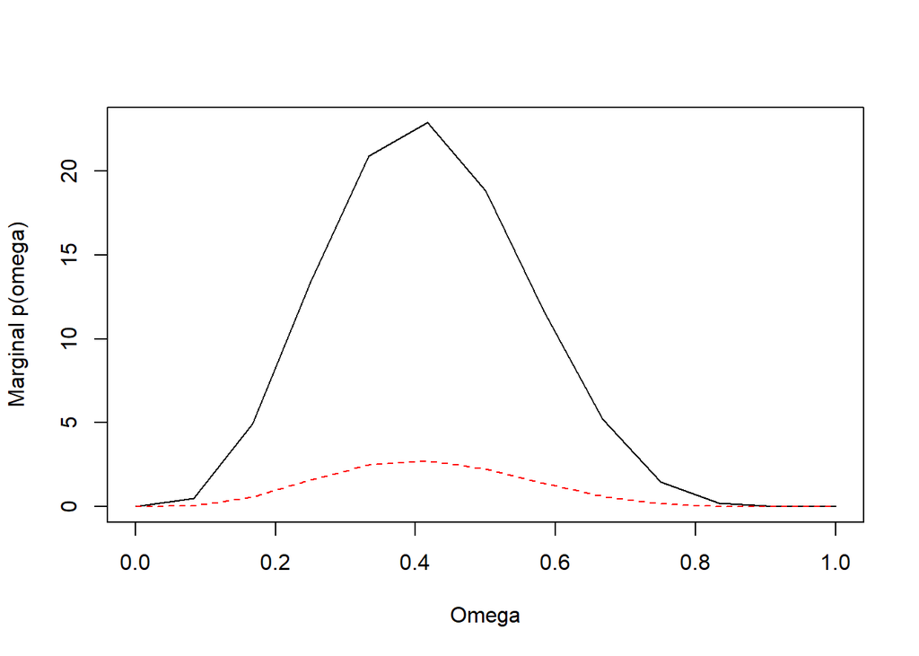

```r
dens<-expand.grid(Omega,Theta)

colnames(dens)<-c("Omega","Theta")

dens$Prior<-apply(dens,1,function(z) jointPrior(z[1],z[2],A_omega,B_omega,K))

Prior.theta.omega<-matrix(dens$Prior,13,13)
Prior.theta.omega<-Prior.theta.omega/sum(Prior.theta.omega) #Joint prior

Prior.omega.marginal<-apply(Prior.theta.omega,2,sum)
Prior.omega.marginal<-Prior.omega.marginal/sum(Prior.omega.marginal)*100 #Omega marginal prior
matplot(Omega,cbind(Prior.omega.marginal,dbeta(Omega,A_omega,B_omega)),type="l",ylab="Marginal p(omega)")
```

Now we have our marginal prior.

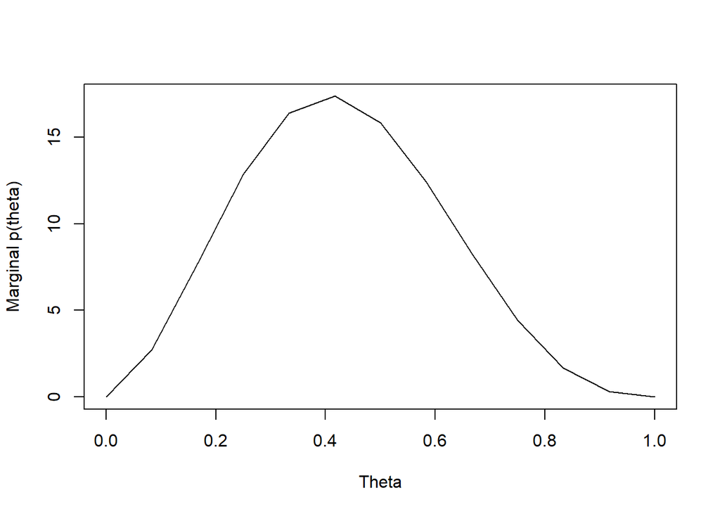

```r
Prior.theta.marginal<-apply(Prior.theta.omega,1,sum)
Prior.theta.marginal<-Prior.theta.marginal/sum(Prior.theta.marginal)*100 #Theta marginal prior
plot(Theta,Prior.theta.marginal,type="l",ylab="Marginal p(theta)")
```

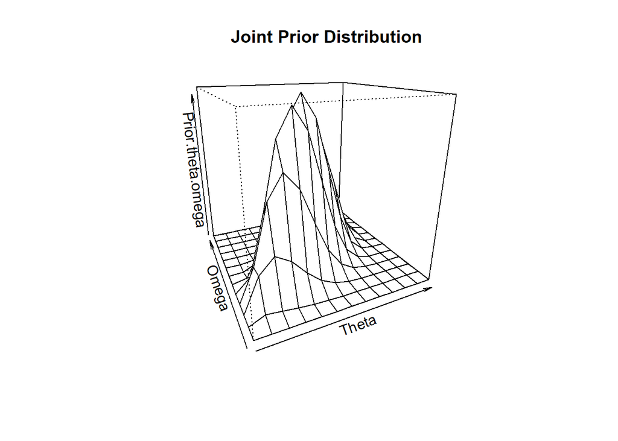

```r
persp(Theta,Omega,Prior.theta.omega,d=1,theta=-25,phi=20,main="Joint Prior Distribution")
```

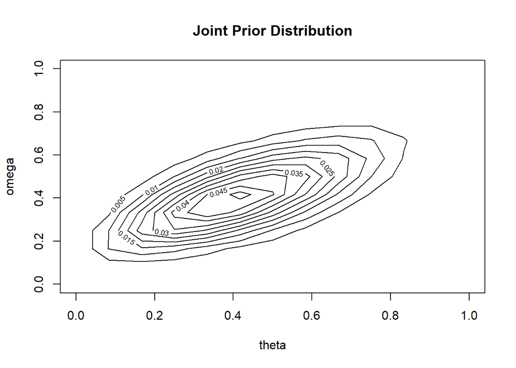

```r
contour(x=Omega,y=Theta,z=Prior.theta.omega,ylab="omega",xlab="theta",main="Joint Prior Distribution")
```

Now we can look at our plots of marginal prior for THeta.

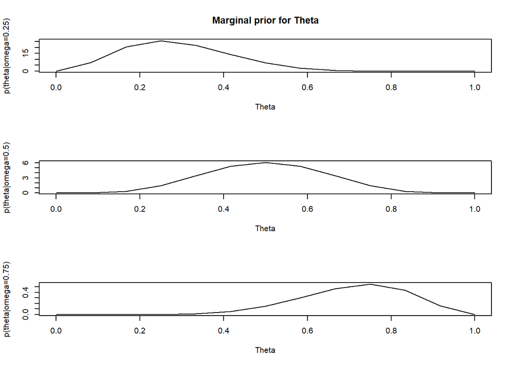

```r
par(mfrow=c(3,1))
Prior.theta.omega.25<-jointPrior(Theta,0.25,A_omega,B_omega,K)
Prior.theta.omega.25<-Prior.theta.omega.25/sum(Prior.theta.omega.25)*100
plot(Theta,Prior.theta.omega.25,type="l",ylab="p(theta|omega=0.25)",main="Marginal prior for Theta")
Prior.theta.omega.5<-jointPrior(Theta,0.5,A_omega,B_omega,K)
Prior.theta.omega.5<-Prior.theta.omega.5/sum(Prior.theta.omega.5)*100
plot(Theta,jointPrior(Theta,0.5,A_omega,B_omega,K),type="l",ylab="p(theta|omega=0.5)")
Prior.theta.omega.75<-jointPrior(Theta,0.75,A_omega,B_omega,K)
Prior.theta.omega.75<-Prior.theta.omega.75/sum(Prior.theta.omega.75)*100
plot(Theta,jointPrior(Theta,0.75,A_omega,B_omega,K),type="l",ylab="p(theta|omega=0.75)")
```

Now let’s look at our optimal theta by likelihood.It sits right underneath .3.

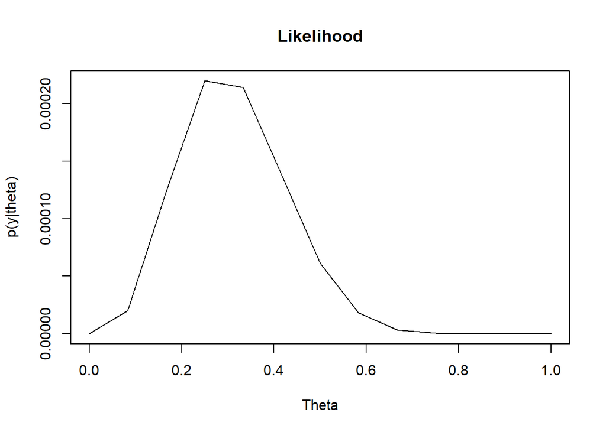

```r
par(mfrow=c(1,1))

likeli<-function(theta,s,k){
  theta^k*(1-theta)^(s-k)
}
likelihood<-likeli(Theta,14,4)
plot(Theta,likelihood,type="l",ylab="p(y|theta)",main="Likelihood")
```

```r
Posterior<-apply(Prior.theta.omega,2,function(z) z*likelihood)
Posterior<-Posterior/sum(Posterior)
```